# Random Forest Analysis of Heart Failure Dataset

Tim Leschke, Pamela Mishaw, Sierra Landacre, Pallak Singh

## Random Forest

- Random Forest is a promising machine learning model because it correctly classifies data from large data sets, is resistant to outliers, and is easy to use.
- Random Forest is a group of decision trees (a forest) that are created from identically distributed, independent random samples of data drawn with replacement from the original dataset (Breiman 2001).

## Methods

- Random Forest Algorithm
- Generation of a Random Forest
- Formulas

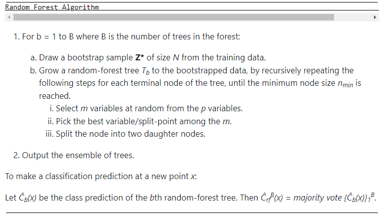

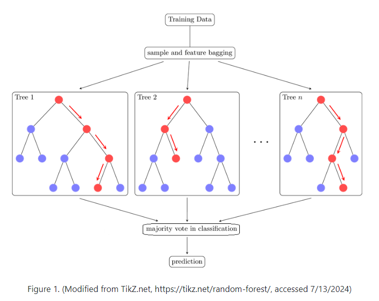

- Figure 1 shows the generation of a Random Forest. The uniqueness of each tree, as a result of random data samples, allows the ensemble to avoid misclassification, and improve classification accuracy.

The *Gini Index* is referred to as a measure of node purity (James et al. 2021). It can also be used to measure the importance of each predictor. The Gini Index is defined by the following formula where K is the number of classes and ${\hat{p}_{mk}}$ is the proportion of observations in the *m*th region that are from the *k*th class. A Gini Index of 0 represents perfect purity.

$$D=-\sum_{n=1}^{K} {\hat{p}_{mk}}(1-\hat{p}_{mk})$$

*Bagging* is the aggregation of the results from each decision tree. It is defined by the following formula where B is the number of training sets and $\hat{f}^{*b}$ is the prediction model. Although bagging improves prediction accuracy, it makes interpreting the results harder as they cannot be visualized as easily as a single decision tree (James et al. 2021).

$${\hat{f}bag(x) = 1/B \sum_{b=1}^{B}\hat{f}^{*b}(x)}$$

## Data Used

- Heart Failure Table
- Dataset Information

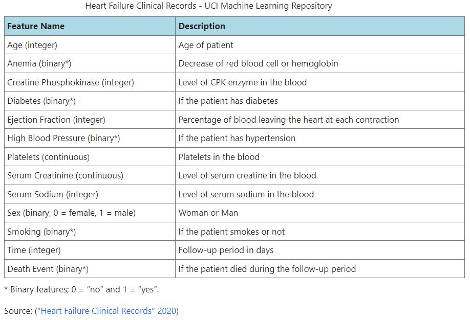

- The dataset comes from the Faisalabad Institute of Cardiology and the Allied Hospital in Faisalabad Pakistan and consists of the medical records of 299 patients who experienced heart failure (Chicco and Jurman 2020).
- There are 299 patient records with 13 features per record.
- We use this dataset to create and evaluate a Random Forest model used for predicting heart failure events for patients.

## Model Evaluation Metrics

- OOB error rate/accuracy
- Confusion Matrix
- AUC-ROC
- The Out-of-Bag data is the data left unused by an individual predictor (decision tree) after a bootstrap sample is taken from the original data set.
- The OOB data is used for internal validation– the prediction error rate is taken after running the “unseen” data through each tree and averaged to provide the overall OOB error rate. (Breiman 2001)
- Shows the values of True Negative, False Negative, False Positive, and True Positive predictions produced by a model.
- Precision: This metric quantifies how many of the observations labeled as positive are actually positive (Raschka, Liu, and Mirjalili 2022).
- Recall: It quantifies how many of the positive observations have been predicted as positive (Raschka, Liu, and Mirjalili 2022).
- F1 Score: Is the harmonic mean of the precision and recall and so used to assess predictive performance. (Raschka, Liu, and Mirjalili 2022).
- Balanced Accuracy: Aids in reducing the effects of class imbalance in the data set so that accuracy of predicting the dominant class does not conceal the classification accuracy for the minority class (Brodersen et al. 2010).
- Area under the receiver operating characteristic curve.
- This is the model’s true positive rate (on the Y-axis) is plotted against the false positive rate (on the X-axis) using varying classification thresholds (Huang and Ling 2005).

## Model Results

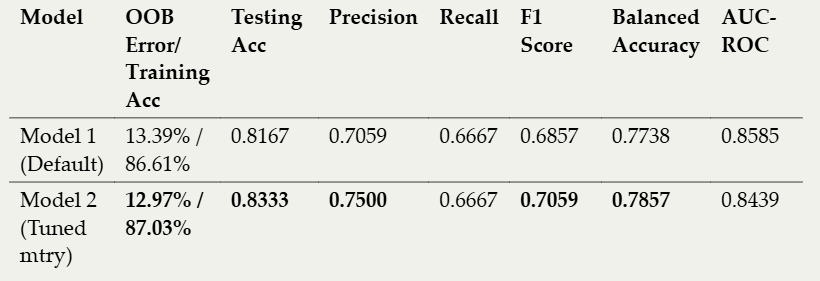

- The testing accuracies of both models are slightly lower than their respective training accuracies which indicates overfitting of the training dataset.
- The performance of model 2 is better than model 1. This is based off of the model’s training and testing accuracies; precision; F1; and balanced accuracy as they are all higher than those of the default model.

## References

Chicco, Davide, and Giuseppe Jurman. 2020. “Machine Learning Can Predict Survival of Patients with Heart Failure from Serum Creatinine and Ejection Fraction Alone.” *BMC Medical Informatics and Decision Making* 20: 1–16.

James, Gareth, Daniela Witten, Hastie Trevor, and Robert Tibshirani. 2021. *An Introduction to Statistical Learning, 2nd Edition*. Springer of New York.